# Watching Hockey Games While Wearing a Jersey: An Analysis

Phil Henrickson

2023-05-10

```r
# knitr chunk options
knitr::opts_chunk$set(echo = T,
                      error=F,
                      warning = F,
                      dev="png",
                      fig.align = 'center',
                      out.width = '80%')

# options for displaying
options(knitr.duplicate.label = "allow",
        scipen = 999)
```

```r
# ggplot theme
theme_phil <- function () {

        ggplot2::theme_minimal() %+replace%
                theme(
                        axis.title = element_text(),
                        # strip.background = element_rect(fill="grey100"),
                        #strip.text = element_text(colour = 'black'),
                        #  strip.text.x = element_text(size = 7),
                        #  strip.text.y = element_text(size = 7),
                        legend.position = "top",
                        # plot.subtitle = element_text(size = 10,
                        #                              hjust = 0),
                        axis.text.x = element_text(size=rel(0.9),
                                                   vjust = 1),
                        axis.text.y = element_text(size=rel(0.9),
                                                   hjust = 1),
                        plot.caption = element_text(size=8,
                                                    hjust = 1,
                                                    vjust = 1,
                                                    margin = unit(c(6,0,0,0), "points")),
                        legend.title = element_blank(),
                        panel.grid.major = element_blank(),
                        panel.spacing = unit(6.5, "mm"),
                        plot.title = element_text(hjust = 0.5, size = 16),
                        plot.subtitle =  element_text(hjust = 0.5),
                        strip.text.x = element_text(size = 12),
                        panel.grid = element_line(colour = "grey90")

                )
}

# colors for stars games
stars_colors = teamcolors %>%
        filter(league == 'nhl') %>%
        filter(name == 'Dallas Stars')
```

```r
add_gt = function(data) {

        data %>%
                gt() %>%
                gt::tab_options(table.width = '80%',
                                table.font.size = 12)
}

clean_jersey = function(x) {

        x = str_replace(x, "jersey", "Jersey ")
        x = str_to_title(x)
        x = str_replace(x, "Rr", "RR")
        x = factor(x,
                   levels = c('No Jersey ',
                              'Robertson Home RR',
                              'Pavelski Away',
                              'Seguin Home',
                              'Benn Home Blackout',
                              'Heiskanen Away RR'))
        x
}

clean_term = function(data) {

        data %>%
                mutate(term = gsub("jersey", "", term),
                       term = gsub("wday", "", term),
                       term = gsub("team_home_away", "team ", term),
                       term = gsub("_", " ", term),
                       term = str_to_title(term),
                       term = gsub("Rr", "RR", term))
}
```

# 1 Data

Load in my jersey labels and Stars game data (from the NHL API) for 22-23, combining these into one dataset.

```r
# load in jersey labels
jerseys = data.table::fread(here::here("data", "jerseys", "cleaned_2223.csv"))

# load in games
games = readRDS(here::here("data", "games", "team_games_2223.Rdata")) %>%
        rename(team.id = team.team.id,
               team.name = team.team.name,
               team.link = team.team.link,
               opponent.id = opponent.team.id,
               opponent.name = opponent.team.name,
               opponent.link = opponent.team.link,
               outcome_binary = outcome.team.binary,
               outcome_ordinal = outcome.team.ordinal) %>%
        mutate(team_won = case_when(outcome_binary == 'win' ~ 'yes',
                                    TRUE ~ 'no')) %>%
        set_names(., gsub("\\.", "_", names(.))) %>%
        mutate(date = as.Date(date)) %>%
        as_tibble()

# join up and clean
games_jerseys = bind_cols(jerseys,
                          games) %>%
        mutate(date = as.Date(date)) %>%
        mutate(jersey_worn = case_when(jersey == 'no jersey' ~ 'no',
                                       TRUE ~ 'yes'),
               jersey_type = factor(case_when(grepl("home", jersey) ~ 'home',
                                              grepl("away", jersey) ~ 'away',
                                              TRUE ~ 'no jersey'),
                                    levels = c('no jersey',
                                               'home',
                                               'away'))) %>%
        mutate(jersey = factor(jersey,
                               levels = c("no jersey",
                                          "seguin home",
                                          "pavelski away",
                                          "benn home blackout",
                                          "robertson home rr",
                                          "heiskanen away rr")))
```

# 2 Games

Create a calendar of games played.

```r
# empty dates for the nhl calendar year
dates =
        tibble(date = seq(as.Date("2022-10-01"),
                          as.Date("2023-05-31"),
                          by = 1)) %>%
        mutate(Year=year(date),
               Month = month(date, label=TRUE, abbr=FALSE),
               Day = wday(date, label=TRUE),
               mday = mday(date),
               Month_week = (5 + day(date) + wday(floor_date(date, 'month'))) %/% 7) %>%
        filter(date < as.Date("2023-04-30")) %>%
        # join with games
        left_join(.,
                  games_jerseys) %>%
        mutate(game_played = case_when(team_won %in% c("yes", "no") ~ 'yes',
                                       TRUE ~ 'no'))
```

```r
# blank calendar
calendar =
        dates %>%
        ggplot(aes(y=Month_week, x=Day))+
        geom_tile(color="white", )+
        geom_text(aes(label = mday),
                  color = 'white',
                  size = 8) +
        facet_wrap(Year~Month, ncol=4)+
        scale_y_continuous(breaks = scales::pretty_breaks())+
        scale_y_reverse()+
        theme_phil()+
        ylab("")+
        theme(axis.text.y = element_blank())+
        xlab("")+
        theme(legend.title = element_text())+
        guides(fill = guide_legend(title.position = 'top',
                                   title = 'Stars Win?'))
```

These are the Stars games on the calendar for the 22-23 season, broken down by outcome. Victory Green = win indicates a win, black = loss.

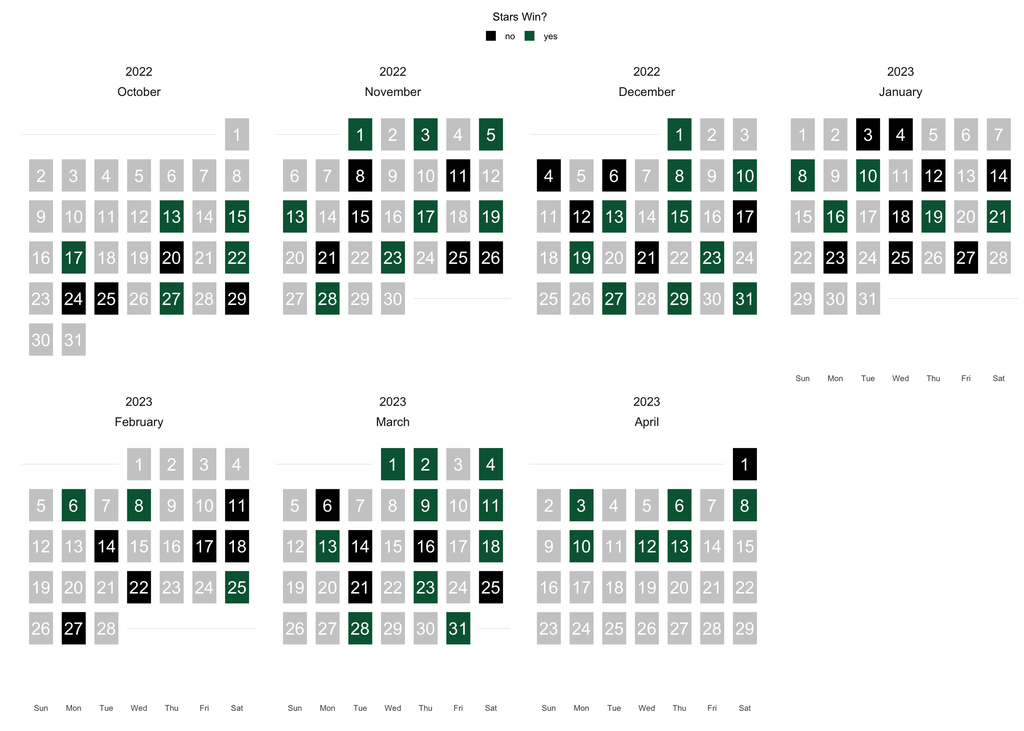

```r
calendar +
        geom_tile(color = 'white',
                  aes(fill = team_won),
                  linewidth = 4)+
        geom_text(aes(label = mday),
                  color = 'white',
                  size = 6)+
        scale_fill_manual(values = c("black", stars_colors$secondary),
                          na.value = 'grey80',
                          breaks = c('no', 'yes'))
```

The Stars won 47 out of 82 games this year (with a whole heck of a lot of losses occuring in OT).

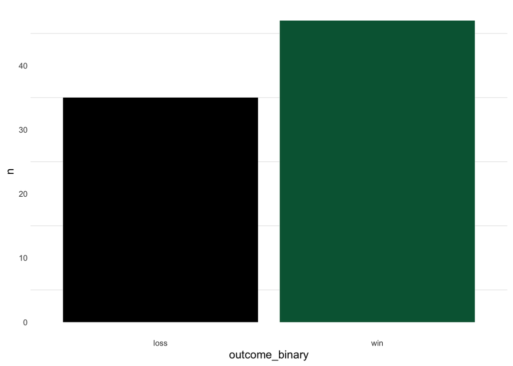

```r
# display wins losses
games_jerseys %>%
        group_by(outcome_binary) %>%
        count() %>%
        ggplot(aes(x=outcome_binary,
                   fill = outcome_binary,
                   y = n))+
        geom_col()+
        theme_phil() +
        scale_fill_manual(values = c("black", stars_colors$secondary))+
        guides(fill = 'none')
```

```r
# table of breakdown by type
games_jerseys %>%
        group_by(outcome_ordinal) %>%
        count()
```

```
## # A tibble: 6 × 2
## # Groups:   outcome_ordinal [6]
##   outcome_ordinal     n
##   <chr>           <int>
## 1 overtime loss      11
## 2 overtime win        4
## 3 regulation loss    21
## 4 regulation win     39
## 5 shootout loss       3
## 6 shootout win        4
```

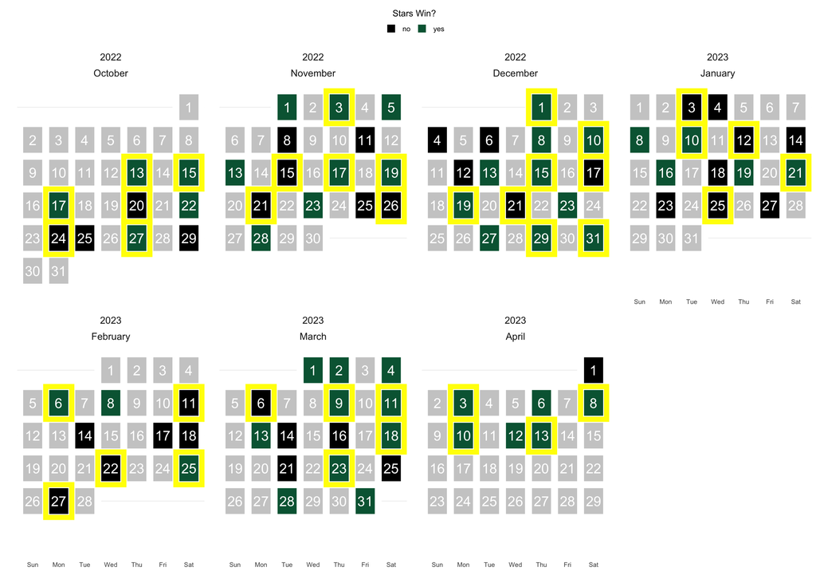

```r
calendar +
        geom_tile(color = 'white',
                  aes(fill = team_won),
                  linewidth = 4)+
        geom_tile(data = dates %>%
                          filter(jersey_worn == 'yes'),
                  fill = NA,
                  color = "yellow",
                  linewidth = 3) +
        geom_text(aes(label = mday),
                  color = 'white',
                  size = 6) +
        scale_fill_manual(values = c("black", stars_colors$secondary),
                          na.value = 'grey80',
                          breaks = c('no', 'yes'))
```

# 3 Analysis

## 3.1 Wins (Binary) and Jerseys (Binary)

The basic question: did the Stars win more or less games when I wore a jersey vs when I did not?

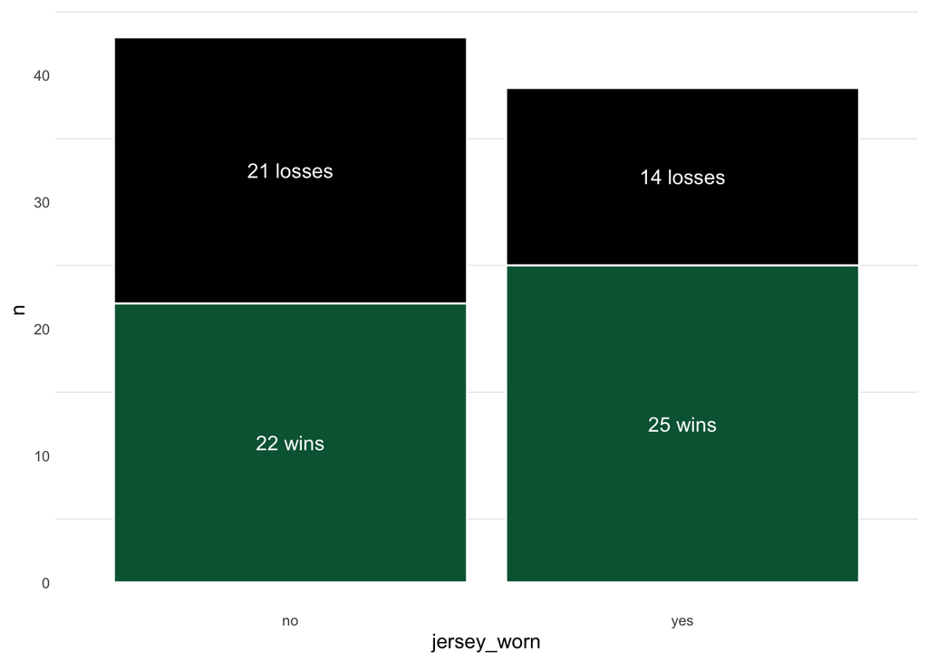

```r
# bar chart
games_jerseys %>%
        group_by(jersey_worn,
                 team_won) %>%
        count() %>%
        group_by(jersey_worn) %>%
        mutate(prop = n / sum(n)) %>%
        mutate(label = case_when(team_won == 'yes' ~ 'wins',
                                 team_won == 'no' ~ 'losses')) %>%
        ggplot(aes(x=jersey_worn,
                   y = n,
                   fill = team_won))+
        geom_col(color = 'white')+
        geom_text(color = 'white',
                  aes(label = paste(n, label)), position = position_stack(vjust = .5)) +
        scale_fill_manual(values = c('black', stars_colors$secondary))+
        theme_phil()+
        theme(legend.title = element_text())+
        guides(fill = 'none')
```

Turns out they actually won slightly more.

This might be easier to intrepret by looking at the win percentage in games I was wearing a jersey vs games in which I was not: they won 64% of the games in which I wore a jersey, and 51% of games in which I did not.

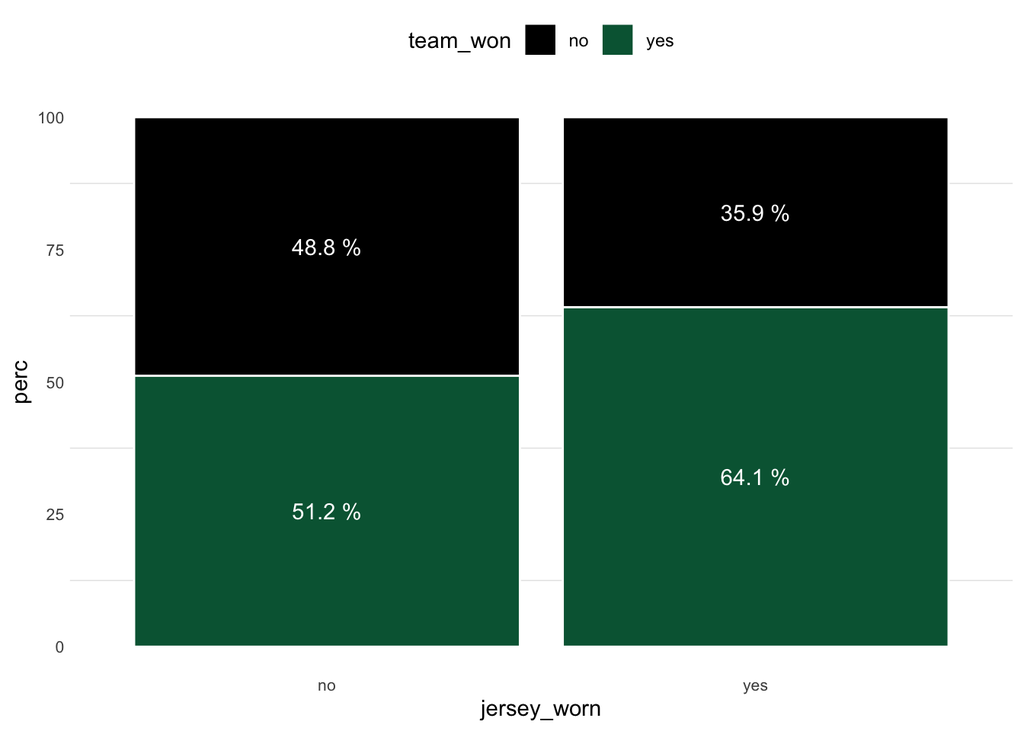

```r
# proportion chart
games_jerseys %>%
        group_by(jersey_worn,
                 team_won) %>%
        count() %>%
        group_by(jersey_worn) %>%
        mutate(perc = n / sum(n) * 100) %>%
        ggplot(aes(x=jersey_worn,
                   y = perc,
                   fill = team_won))+
        geom_col(color = 'white')+
        geom_text(color = 'white',
                  aes(label = paste(round(perc, 1), "%")), position = position_stack(vjust = .5)) +
        scale_fill_manual(values = c('black', stars_colors$secondary))+
        theme_phil()+
        theme(legend.title = element_text())
```

Is this evidence that my jersey has a relationship with the Stars winning or losing? For this we turn to the logic of hypothesis testing. How often would we expect to see a difference in win proportions like this in a world where my jersey had no effect?

How do we test this?

Find the difference in proportions between games won when I was wearing a jersey vs games won when I was not.

```r
# get observed difference in proportions
d_hat <- games_jerseys %>%
        observe(team_won ~ jersey_worn, success = "yes",
                stat = "diff in props", order = c("yes", "no"))

# calculate this manually
```

Then, simulate the difference in proportions that we would observe **given that there is no difference between games in which I was wearing a jersey or not**. This gives us the range of expected differences in proportions we would observe simply by random chance alone, given our sample.

This means in practice that I’ll simulate a series of datasets in which we know that jersey has no effect on the outcome. I run 10k simulations via permutation (randomly shuffling around the games), creating 10k datasets of 82 games.

```r
# simulate a null distribution
set.seed(1999)
sims_null_dist_d =
        games_jerseys %>%
        specify(team_won ~ jersey_worn, success = "yes") %>%
        hypothesize(null = 'independence') %>%
        generate(reps = 10000, type = 'permute')

# how many records
# nrow(sims_null_dist_d)
```

For example, we can pull out a few random samples to see what the difference between jersey/no jersey and win/loss may have looked given no relationship between the two.

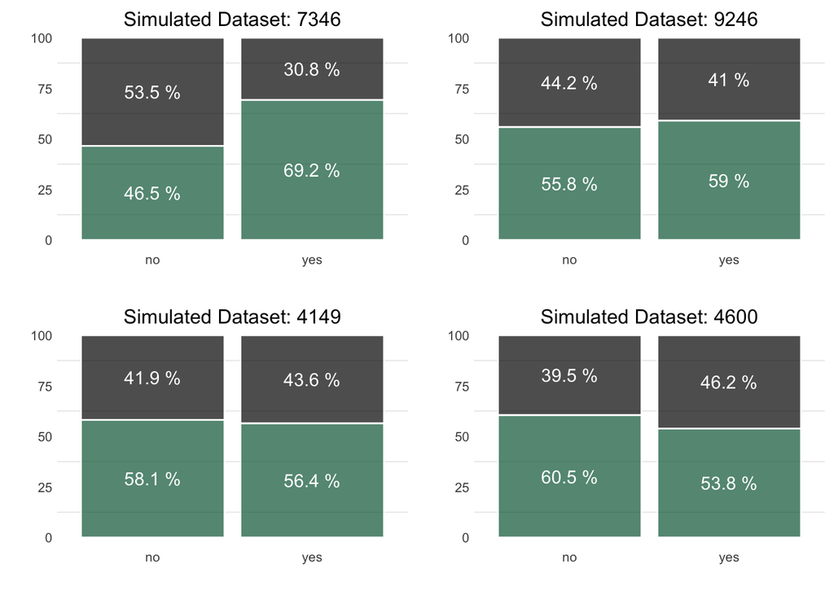

```r
# show some simluations
set.seed(2000)
samples = sample(1:10000, 4)

# function to plot sample
plot_sample = function(sample) {

        sims_null_dist_d %>%
                filter(replicate %in% sample) %>%
                group_by(jersey_worn,
                         team_won) %>%
                count() %>%
                group_by(jersey_worn) %>%
                mutate(perc = n / sum(n) * 100) %>%
                ggplot(aes(x=jersey_worn,
                           y = perc,
                           fill = team_won))+
                geom_col(color = 'white',
                         alpha = 0.7)+
                geom_text(color = 'white',
                          aes(label = paste(round(perc, 1), "%")), position = position_stack(vjust = .5)) +
                scale_fill_manual(values = c('black', stars_colors$secondary))+
                theme_phil()+
                theme(legend.title = element_text())+
                ggtitle(paste("Simulated Dataset:", sample))+
                guides(fill = 'none')+
                xlab("")+
                ylab("")+
                theme(plot.title = element_text(hjust = 0.5, size = 12))


}

# plot four
cowplot::plot_grid(
        plot_sample(samples[1]),
        plot_sample(samples[2]),
        plot_sample(samples[3]),
        plot_sample(samples[4])
)
```

How does the real data compare to the simulated distribution?

I can visualize the distribution of the test statistic in simulations (difference in proportions) then overlay my observed test statistic.

How frequently would we observe a test statistic as extreme as the one I found, in either direction, given that there’s no relationship between my wearing a jersey and the outcome? About 33% of the time.

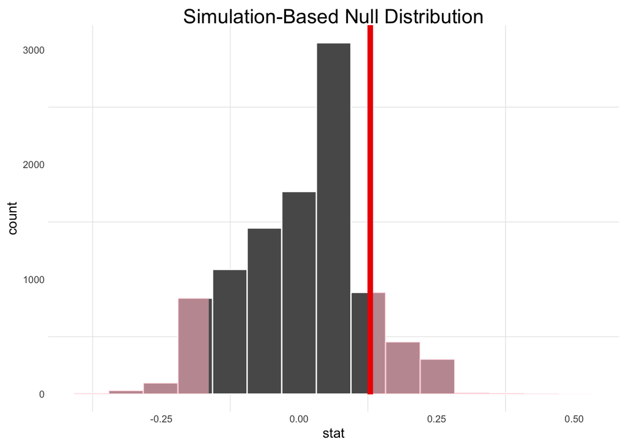

```r
# shade p value
sims_null_dist_d %>%
        calculate(stat = 'diff in props', order = c("yes", "no")) %>%
        visualize() +
        shade_p_value(d_hat,
                      direction = 'two-sided')+
        theme_phil()
```

```r
# directly calculate p value
sims_null_dist_d %>%
        calculate(stat = 'diff in props', order = c("yes", "no")) %>%
        get_p_value(d_hat, direction = 'two-sided')
```

```
## # A tibble: 1 × 1
##   p_value
##     <dbl>
## 1   0.334
```

In essence, there’s no evidence of a difference here.

In other words, we are well within the realm of what we would expect to see given no relationship. The jersey doesn’t have an effect, people.

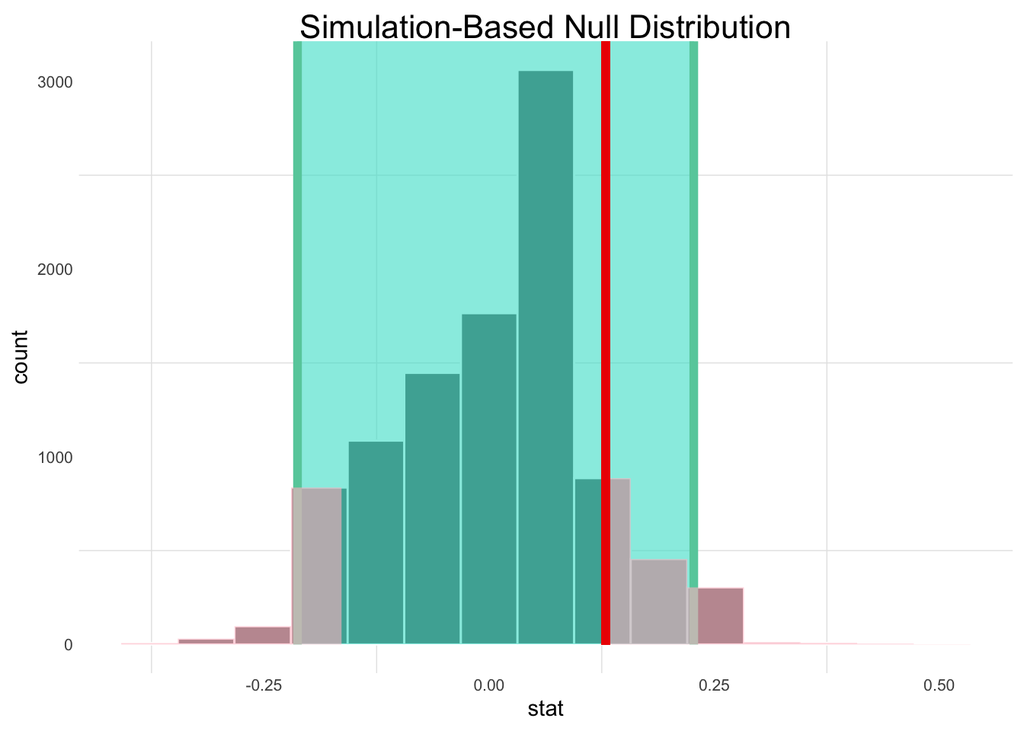

```r
# get ci
ci = get_confidence_interval(sims_null_dist_d %>%
                                     calculate(stat = 'diff in props', order = c("yes", "no")),
                             level = .95)

# shade p value
sims_null_dist_d %>%
        calculate(stat = 'diff in props', order = c("yes", "no")) %>%
        visualize() +
        shade_confidence_interval(ci)+
        shade_p_value(d_hat,
                      direction = 'two-sided')+
        theme_phil()
```

How many more games would the Stars have needed to win while I was wearing a jersey to change this finding?

Another way of looking at this: how many wins would the Stars have typically had if I just randomly selected the 39 games in which I was wearing a jersey? This the distribution of wins in those simulations; the green line indicates how many they won in the 39 in which I actually won a game.

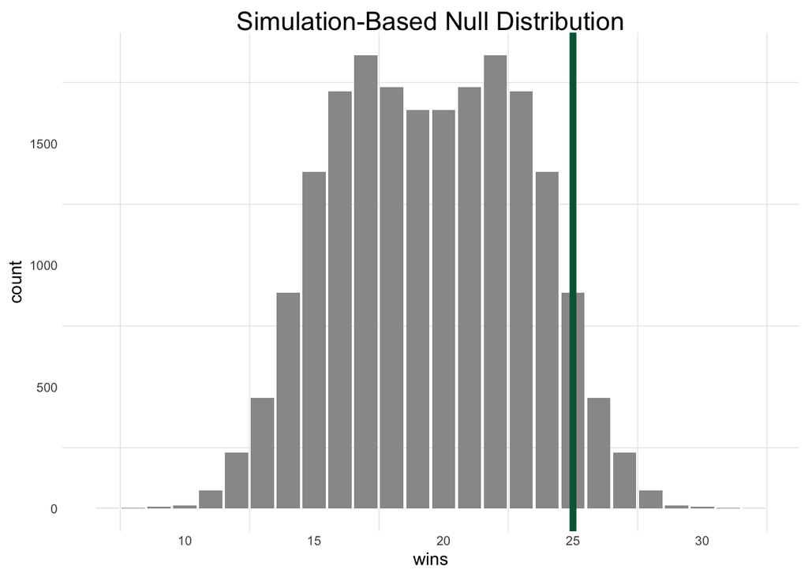

```r
sim_wins =
        sims_null_dist_d %>%
        group_by(replicate) %>%
        filter(jersey_worn == 'yes') %>%
        group_by(replicate, team_won) %>%
        count() %>%
        group_by(replicate) %>%
        mutate(prop = n / sum(n))

# wins
sim_wins %>%
        ggplot(aes(x=n))+
        geom_bar(fill = 'grey60')+
        geom_vline(xintercept = 25,
                   color = stars_colors$secondary,
                   size = 2)+
        theme_phil()+
        xlab("wins")+
        ggtitle("Simulation-Based Null Distribution")
```

How many more wins would they have needed while I was wearing my jersey to think there was anything interesting going on here? The 95% confidence interval for a two-sided test ranges from 18 wins to 27 wins; if they had won 3 more games things could be interesting.

```r
# at the high end
high_ci = sims_null_dist_d %>%
        group_by(replicate) %>%
        filter(jersey_worn == 'yes' & team_won == 'yes') %>%
        group_by(replicate, team_won) %>%
        count() %>%
        arrange(desc(n)) %>%
        ungroup() %>%
        filter(row_number() == 250) %>%
        pull(n)

# at the low end
low_ci = sims_null_dist_d %>%
        group_by(replicate) %>%
        filter(jersey_worn == 'yes' & team_won == 'yes') %>%
        group_by(replicate, team_won) %>%
        count() %>%
        arrange(desc(n)) %>%
        ungroup() %>%
        filter(row_number() == 9750) %>%
        pull(n)

paste("95% CI: ", "[", low_ci, ",", high_ci, "]", sep = "")
```

```
## [1] "95% CI: [18,27]"
```

Just a note: I was wearing my Heiskanen jersey for the game we lost to the Rangers in OT after giving up a goal at the buzzer, and I was wearing my Robertson jersey for the game we lost to Calgary on a breakaway in the final minute.

## 3.2 Wins (Binary) and Jerseys (Categorical)

Okay, but I wore different types of jerseys. Surely, we must have some interesting evidence if we break down the games by jersey?

How do we test whether there’s anything going on here? Same as before, but now we’ll use a Chi squared test statistic instead of the difference in proportions.

### 3.2.1 Jerseys by Type

First, look by jersey type (home, away, no jersey).

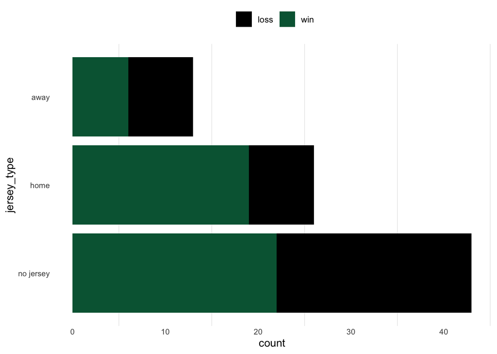

```r
games_jerseys %>%
        ggplot(aes(y=jersey_type,
                   fill = outcome_binary))+
        geom_bar()+
        theme_minimal()+
        scale_fill_manual(values = c('black', stars_colors$secondary))+
        theme_phil()
```

How do we test this? Same approach as before. Calculate the Chisq test statistic. Then generate the null distribution and grab the p-value.

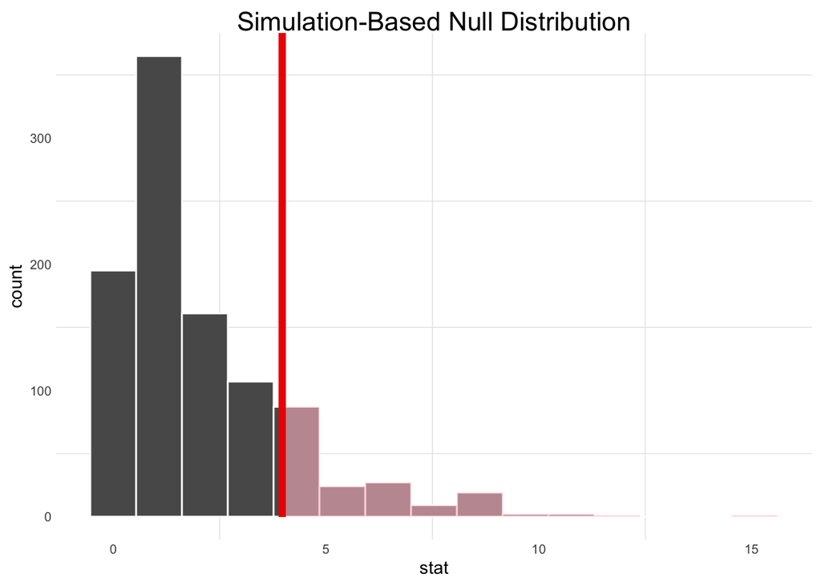

```r
Chisq_hat = games_jerseys %>%
        observe(team_won ~ jersey_type, stat = 'Chisq')

# sim
null_dist_sim =
        games_jerseys %>%
        specify(team_won ~ jersey_type) %>%
        hypothesize(null = 'independence') %>%
        generate(reps = 1000, type = 'permute') %>%
        calculate(stat = 'Chisq')

# visualize and overlay p value
null_dist_sim %>%
        visualize()+
        shade_p_value(Chisq_hat, direction = 'greater')+
        theme_phil()
```

```r
# p value
null_dist_sim %>%
        get_p_value(obs_stat = Chisq_hat, direction = 'greater')
```

```
## # A tibble: 1 × 1
##   p_value
##     <dbl>
## 1   0.161
```

Hmm. Not significant at conventional levels.. No matter. Obviously, it’s the player of the jersey that matters.

### 3.2.2 Jerseys By Player

Now looking at the specific player and jersey.

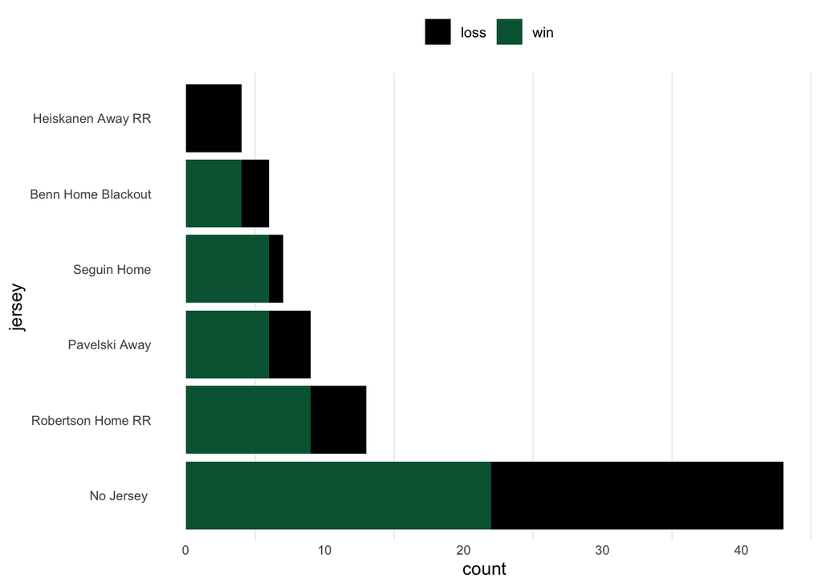

```r
games_jerseys %>%
        mutate(jersey = clean_jersey(jersey)) %>%
        ggplot(aes(y=jersey,
                   fill = outcome_binary))+
        geom_bar()+
        theme_minimal()+
        scale_fill_manual(values = c('black', stars_colors$secondary))+
        theme_phil()
```

Calculate the Chisq test statistic under the hypothesis of independence.

```r
Chisq_hat <- games_jerseys %>%
        specify(team_won ~ jersey) %>%
        hypothesize(null = "independence") %>%
        calculate(stat = "Chisq")

Chisq_hat
```

```
## Response: team_won (factor)
## Explanatory: jersey (factor)
## Null Hypothesis: independence
## # A tibble: 1 × 1
##    stat
##   <dbl>
## 1  9.63
```

Next, we’ll simulate a null distribution, which we can visualize (alongside the theoretical distribution).

```r
set.seed(1999)
null_dist_sim <- games_jerseys %>%
        specify(team_won ~ jersey) %>%
        hypothesize(null = "independence") %>%
        generate(reps = 1000, type = "permute") %>%
        calculate(stat = "Chisq")

# visualize
suppressWarnings({
        null_dist_sim %>%
                visualize(method = 'both') +
                shade_p_value(obs_stat = Chisq_hat,
                              direction = 'greater') +
                theme_phil()
})
```

[figure not shown]

How likely would we observe this under the null?

```r
null_dist_sim %>%
        get_p_value(Chisq_hat, direction = 'greater')
```

```
## # A tibble: 1 × 1
##   p_value
##     <dbl>
## 1   0.074
```

Well, well, well. Looks like we have significance at the 10% level! That is science by some conventions! Let’s run using the base chisq_test to “confirm”.

```r
# this is the more correct version
# chisq_test(games_jerseys, team_won ~ jersey, simulate.p.value = T)

chisq_test(games_jerseys, team_won ~ jersey)
```

```
## # A tibble: 1 × 3
##   statistic chisq_df p_value
##       <dbl>    <int>   <dbl>
## 1      9.63        5  0.0863
```

Just ignore that warning. We’ve got statistical significance at the 10% level, baby. Let’s go.

What does this mean? Well, less than 10% of the time would we observe a test statistic as extreme as this under the null hypothesis of no relationship. Just ignore the fact that we have different sample sizes. Or that we’ve tested multiple hypothses. We are abusing statistics here, get with the program.

Let’s run a linear model to test this as well. I’ll fit a linear probability model as the Heiskanen jersey has perfect separation and I don’t want to be bothered with separation issues in a logistic regression. I’ll just use robust and/or bootstrapped standard errors for inference.

```r
# linear probability model of team won
lm = lm(team_won ~ jersey,
        data = games_jerseys %>%
                mutate(team_won = case_when(team_won == 'yes' ~ 1,
                                            TRUE ~ 0)))

# display tidy output
lm %>%
        tidy(conf.int = T, conf.level = .9) %>%
        clean_term() %>%
        mutate_if(is.numeric, round, 3) %>%
        add_gt()
```

| term | estimate | std.error | statistic | p.value | conf.low | conf.high |
| --- | --- | --- | --- | --- | --- | --- |
| (Intercept) | 0.512 | 0.074 | 6.951 | 0.000 | 0.389 | 0.634 |
| Seguin Home | 0.346 | 0.197 | 1.756 | 0.083 | 0.018 | 0.673 |
| Pavelski Away | 0.155 | 0.177 | 0.876 | 0.384 | -0.140 | 0.450 |
| Benn Home Blackout | 0.155 | 0.210 | 0.737 | 0.463 | -0.195 | 0.505 |
| Robertson Home RR | 0.181 | 0.153 | 1.183 | 0.241 | -0.074 | 0.435 |
| Heiskanen Away RR | -0.512 | 0.252 | -2.028 | 0.046 | -0.932 | -0.092 |

Based on the regression output, we can interpret the following: the Stars win .512 of games in which I did not win a jersey (the intercept, same as what we found earlier).

Wearing the Seguin home jersey increases their win rate by .346, with a standard error of 0.197. The 90% confidence interval for this effect is [0.018, 0.673], which is strictly positive **and is therefore significant at the 10% level, meaning we have done science**.

Wearing a Heiskanen jersey drops this by .512 to zero (they didn’t win any of the four games in which I wore the jersey). This result is **SIGNIFICANT AT THE 5% LEVEL** and is therefore **BIG SCIENCE**.

No evidence of partial effects for the others. Don’t worry about that. Keep the focus on the p-values.

We can see the jerseys are jointly significant by running an F test against an intercept model. That p-value of 0.08 means **we have done science** (but not in all caps).

```r
# intercept only
null = lm(team_won ~ 1,
          data = games_jerseys %>%
                  mutate(team_won = case_when(team_won == 'yes' ~ 1,
                                              TRUE ~ 0)))

# f test
anova(null, lm)
```

```
## Analysis of Variance Table
##
## Model 1: team_won ~ 1
## Model 2: team_won ~ jersey
##   Res.Df    RSS Df Sum of Sq      F  Pr(>F)
## 1     81 20.061
## 2     76 17.704  5    2.3571 2.0237 0.08472 .
## ---
## Signif. codes:  0 '***' 0.001 '**' 0.01 '*' 0.05 '.' 0.1 ' ' 1
```

But, you, the crafty reviewer, are surely protesting - you didn’t use robust standard errors. So let me give (White) robust standard errors.

```r
# white robust standard errors
library(lmtest)
library(sandwich)
coeftest(lm, vcov = vcovHC(lm, type = 'HC0')) %>%
        tidy() %>%
        mutate_if(is.numeric, round, 3) %>%
        clean_term() %>%
        add_gt()
```

| term | estimate | std.error | statistic | p.value |
| --- | --- | --- | --- | --- |
| (Intercept) | 0.512 | 0.076 | 6.712 | 0.000 |
| Seguin Home | 0.346 | 0.153 | 2.263 | 0.026 |
| Pavelski Away | 0.155 | 0.175 | 0.888 | 0.377 |
| Benn Home Blackout | 0.155 | 0.207 | 0.749 | 0.456 |
| Robertson Home RR | 0.181 | 0.149 | 1.213 | 0.229 |
| Heiskanen Away RR | -0.512 | 0.076 | -6.712 | 0.000 |

Look at that, now Seguin’s jersey is conventional at **BIG SCIENCE LEVELS**. Is that the right specification for robust standard errors? Obviously it is, because it made my results more significant.

How do the bootstrapped errors look?

```r
# get bootstrapped standard errors
library(rsample)

# bootstraps
set.seed(1999)
boots = rsample::bootstraps(
        games_jerseys %>%
                mutate(team_won = case_when(team_won == 'yes' ~ 1,
                                            TRUE ~ 0)),
        times = 1000)

# function to fit lm
fit_lm_on_boot <- function(split) {
        lm(team_won ~ jersey, analysis(split))
}

# get bootstraps
boot_models =
        boots %>%
        mutate(model = map(splits, fit_lm_on_boot),
               coef_info = map(model, tidy))

# get boostrapped confidence interval
int_pctl(boot_models,
         coef_info, alpha=0.1) %>%
        mutate_if(is.numeric, round, 3) %>%
        dplyr::select(term, .estimate, .lower, .upper, .alpha, .method) %>%
        clean_term() %>%
        add_gt()
```

| term | .estimate | .lower | .upper | .alpha | .method |
| --- | --- | --- | --- | --- | --- |
| (Intercept) | 0.506 | 0.375 | 0.636 | 0.1 | percentile |
| Benn Home Blackout | 0.161 | -0.214 | 0.512 | 0.1 | percentile |
| Heiskanen Away RR | -0.505 | -0.636 | -0.373 | 0.1 | percentile |
| Pavelski Away | 0.163 | -0.142 | 0.463 | 0.1 | percentile |
| Robertson Home RR | 0.188 | -0.065 | 0.433 | 0.1 | percentile |
| Seguin Home | 0.359 | 0.089 | 0.585 | 0.1 | percentile |

Ignore that warning. Heiskanen’s jersey is still bigly significant, and Seguin’s is still significant as well, so this will do as a robustness check.

Do these results hold up if I add in additional features?

### 3.2.3 Robustness

What if I add home/away as a feature? Still significant?

```r
# add home as a feature
lm(team_won ~ jersey + team_home_away,
   data = games_jerseys %>%
           mutate(team_won = case_when(team_won == 'yes' ~ 1,
                                       TRUE ~ 0))) %>%
        tidy() %>%
        mutate_if(is.numeric, round, 3) %>%
        rmarkdown::paged_table() %>%
        clean_term() %>%
        add_gt()
```

| term | estimate | std.error | statistic | p.value |
| --- | --- | --- | --- | --- |
| (Intercept) | 0.588 | 0.090 | 6.500 | 0.000 |
| Seguin Home | 0.359 | 0.196 | 1.833 | 0.071 |
| Pavelski Away | 0.166 | 0.176 | 0.942 | 0.349 |
| Benn Home Blackout | 0.183 | 0.210 | 0.872 | 0.386 |
| Robertson Home RR | 0.189 | 0.152 | 1.242 | 0.218 |
| Heiskanen Away RR | -0.588 | 0.256 | -2.296 | 0.024 |
| Team Home | -0.157 | 0.109 | -1.436 | 0.155 |

Yep. Good to keep it.

What if I add day of week? Still significant?

```r
# add home and day of week
lm(team_won ~ jersey + team_home_away + wday,
   data = games_jerseys %>%
           mutate(wday = factor(as.character(wday(date, label =T)),
                                levels = c("Sun",
                                           "Mon",
                                           "Tue",
                                           "Wed",
                                           "Thu",
                                           "Fri",
                                           "Sat"))) %>%
           mutate(team_won = case_when(team_won == 'yes' ~ 1,
                                       TRUE ~ 0))) %>%
        tidy() %>%
        mutate_if(is.numeric, round, 3) %>%
        clean_term() %>%
        add_gt()
```

| term | estimate | std.error | statistic | p.value |
| --- | --- | --- | --- | --- |
| (Intercept) | 0.757 | 0.283 | 2.672 | 0.009 |
| Seguin Home | 0.233 | 0.206 | 1.133 | 0.261 |
| Pavelski Away | 0.049 | 0.185 | 0.265 | 0.792 |
| Benn Home Blackout | 0.170 | 0.213 | 0.800 | 0.426 |
| Robertson Home RR | 0.081 | 0.167 | 0.484 | 0.630 |
| Heiskanen Away RR | -0.724 | 0.260 | -2.786 | 0.007 |
| Team Home | -0.135 | 0.112 | -1.209 | 0.231 |
| Mon | -0.193 | 0.313 | -0.618 | 0.539 |
| Tue | -0.292 | 0.308 | -0.949 | 0.346 |
| Wed | -0.286 | 0.320 | -0.892 | 0.375 |
| Thu | 0.126 | 0.311 | 0.403 | 0.688 |
| Fri | -0.333 | 0.335 | -0.996 | 0.323 |
| Sat | -0.091 | 0.303 | -0.301 | 0.764 |

Well, Heiskanen is, but Seguin isn’t anymore. Therefore, doesn’t count as a robustness check.

## 3.3 Goals

Okay so I’ve been looking at binary wins, let me know look at goals per game. Looks like they scored fewer when goals when I wore jerseys?

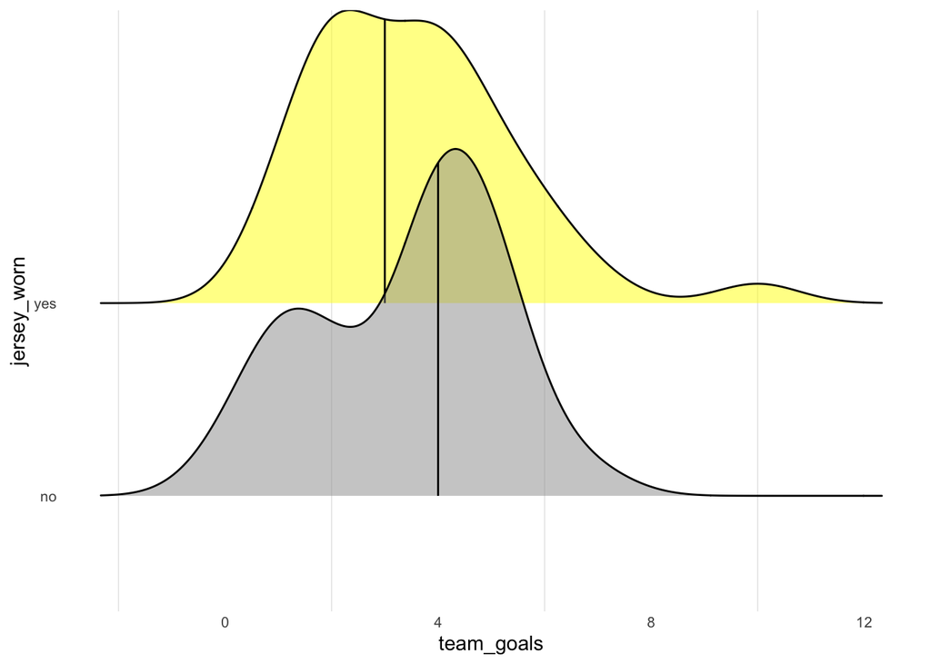

```r
library(ggridges)

games_jerseys %>%
        ggplot(aes(x = team_goals,
                   fill = jersey_worn,
                   y = jersey_worn))+
        stat_density_ridges(quantile_lines = T,
                            quantiles = 0.5,
                            alpha = 0.5)+
        theme_phil()+
        scale_fill_manual(values = c('grey60', 'yellow'))+
        guides(fill = 'none')
```

Is that difference significant? Run a t-test. Nope.

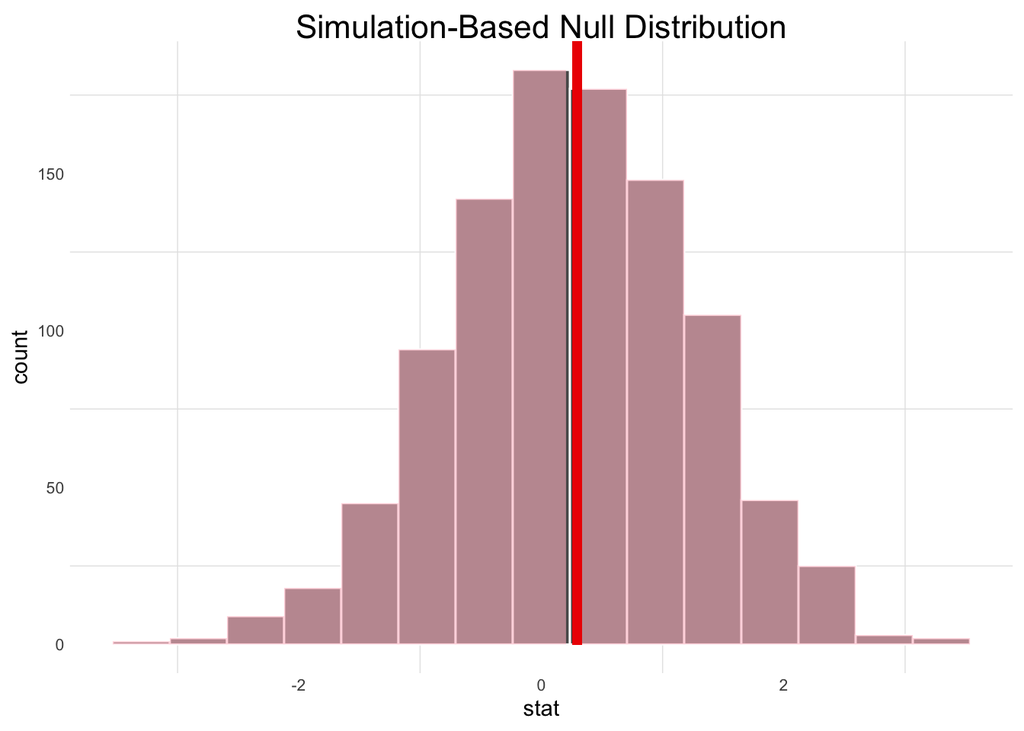

```r
obs_t =
        games_jerseys %>%
        specify(team_goals ~ jersey_worn) %>%
        hypothesize(null = 'independence') %>%
        calculate(stat = "t", order = c("yes", "no"))

null_t =
        games_jerseys %>%
        specify(team_goals ~ jersey_worn) %>%
        hypothesize(null = 'independence') %>%
        generate(reps = 1000, type = 'bootstrap') %>%
        calculate(stat = 't', order = c('yes', 'no'))

null_t %>%
        visualize() +
        shade_p_value(obs_t, direction = 'two-sided')+
        theme_phil()
```

What about by jersey type?

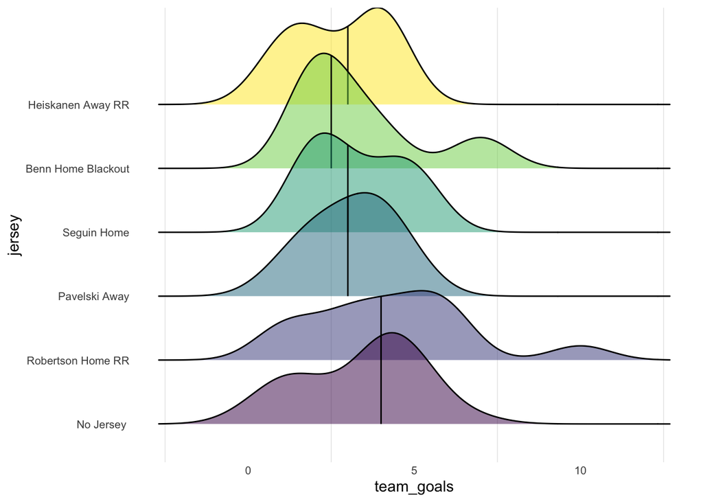

```r
# ridge
games_jerseys %>%
        mutate(jersey = clean_jersey(jersey)) %>%
        ggplot(aes(x = team_goals,
                   fill = jersey,
                   y = jersey))+
        stat_density_ridges(quantile_lines = T,
                            quantiles = 0.5,
                            alpha = 0.5)+
        theme_phil()+
        #  scale_fill_manual(values = c('grey60', 'yellow'))+
        guides(fill = 'none')+
        scale_fill_viridis_d()
```

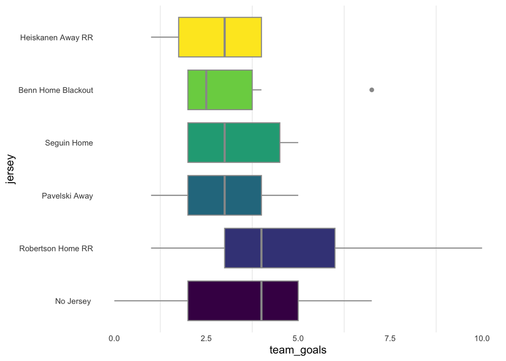

```r
# box plot
games_jerseys %>%
        mutate(jersey = clean_jersey(jersey)) %>%
        ggplot(aes(x = team_goals,
                   fill = jersey,
                   y = jersey))+
        geom_boxplot(color = 'grey60')+
        theme_phil()+
        #  scale_fill_manual(values = c('grey60', 'yellow'))+
        guides(fill = 'none')+
        scale_fill_viridis_d()
```

Well it certainly **looks** like wearing a Jersey leads to less goals on average (if not for stupid Robertson). But the test says nope. Toss it out.

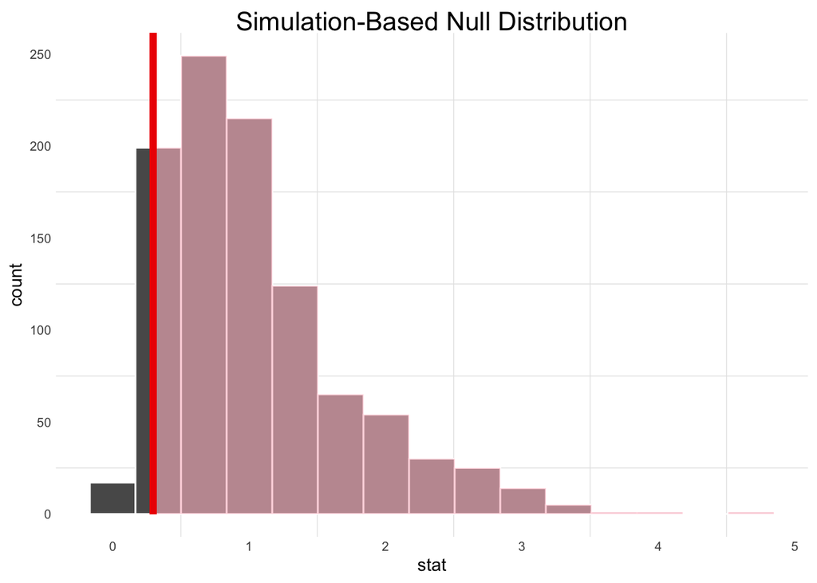

```r
# test
obs_f =
        games_jerseys %>%
        specify(team_goals ~ jersey) %>%
        hypothesize(null = 'independence') %>%
        calculate(stat = "F")

null_f =
        games_jerseys %>%
        specify(team_goals ~ jersey) %>%
        hypothesize(null = 'independence') %>%
        generate(reps = 1000, type = 'permute') %>%
        calculate(stat = 'F')

null_f %>%
        visualize() +
        shade_p_value(obs_t, direction = 'greater') +
        theme_phil()
```

```r
null_f %>%
        get_p_value(obs_stat = null_f,
                    direction = 'greater')
```

```
## # A tibble: 1 × 1
##   p_value
##     <dbl>
## 1   0.417
```

What about running a linear model? Close on Robertson being positive and significant relative to the others. F test says nope though.

```r
lm = lm(team_goals ~ jersey,
        data = games_jerseys)


# coefs
lm %>%
        tidy() %>%
        mutate_if(is.numeric, round, 3) %>%
        clean_term() %>%
        add_gt()
```

| term | estimate | std.error | statistic | p.value |
| --- | --- | --- | --- | --- |
| (Intercept) | 3.419 | 0.279 | 12.271 | 0.000 |
| Seguin Home | -0.133 | 0.745 | -0.178 | 0.859 |
| Pavelski Away | -0.307 | 0.670 | -0.459 | 0.647 |
| Benn Home Blackout | -0.085 | 0.796 | -0.107 | 0.915 |
| Robertson Home RR | 0.889 | 0.578 | 1.538 | 0.128 |
| Heiskanen Away RR | -0.669 | 0.955 | -0.700 | 0.486 |

```r
# glance
lm %>%
        glance() %>%
        mutate_if(is.numeric, round, 3)
```

```
## # A tibble: 1 × 12
##   r.squared adj.r.squared sigma statistic p.value    df logLik   AIC   BIC
##       <dbl>         <dbl> <dbl>     <dbl>   <dbl> <dbl>  <dbl> <dbl> <dbl>
## 1     0.048        -0.015  1.83     0.768   0.576     5  -163.  339.  356.
## # ℹ 3 more variables: deviance <dbl>, df.residual <dbl>, nobs <dbl>
```

What about running a Poisson regression? Close on Robertson as well (basically the same model…).

```r
glm(team_goals ~ jersey,
    family = 'poisson',
    data = games_jerseys) %>%
        tidy(exp=T) %>%
        mutate_if(is.numeric, round, 3) %>%
        clean_term() %>%
        add_gt()
```

| term | estimate | std.error | statistic | p.value |
| --- | --- | --- | --- | --- |
| (Intercept) | 3.419 | 0.082 | 14.904 | 0.000 |
| Seguin Home | 0.961 | 0.224 | -0.177 | 0.860 |
| Pavelski Away | 0.910 | 0.206 | -0.457 | 0.648 |
| Benn Home Blackout | 0.975 | 0.238 | -0.106 | 0.916 |
| Robertson Home RR | 1.260 | 0.157 | 1.472 | 0.141 |
| Heiskanen Away RR | 0.804 | 0.313 | -0.696 | 0.486 |

What if I add in a bunch of stuff? Like day of the week?

Turns out Tuesdays are significantly different (compared to, uh, a Sunday with no jersey) in a Poisson regression! Science!

```r
add_wday = function(x) {
        x %>%
                mutate(wday = factor(as.character(wday(date, label =T)),
                                     levels = c("Sun",
                                                "Mon",
                                                "Tue",
                                                "Wed",
                                                "Thu",
                                                "Fri",
                                                "Sat")))
}

glm(team_goals ~ jersey + team_home_away + wday,
    family = 'poisson',
    data = games_jerseys %>%
            add_wday()) %>%
        tidy() %>%
        mutate_if(is.numeric, round, 3) %>%
        clean_term() %>%
        add_gt()
```

| term | estimate | std.error | statistic | p.value |
| --- | --- | --- | --- | --- |
| (Intercept) | 1.644 | 0.271 | 6.066 | 0.000 |
| Seguin Home | -0.093 | 0.238 | -0.391 | 0.696 |
| Pavelski Away | -0.121 | 0.219 | -0.550 | 0.582 |
| Benn Home Blackout | -0.003 | 0.247 | -0.014 | 0.989 |
| Robertson Home RR | 0.189 | 0.178 | 1.066 | 0.286 |
| Heiskanen Away RR | -0.269 | 0.326 | -0.825 | 0.409 |
| Team Home | -0.052 | 0.126 | -0.416 | 0.678 |
| Mon | -0.415 | 0.311 | -1.335 | 0.182 |
| Tue | -0.639 | 0.315 | -2.026 | 0.043 |
| Wed | -0.395 | 0.322 | -1.225 | 0.221 |
| Thu | -0.257 | 0.306 | -0.841 | 0.400 |
| Fri | -0.405 | 0.342 | -1.187 | 0.235 |
| Sat | -0.347 | 0.297 | -1.168 | 0.243 |

Look at the distributions of goals by day.

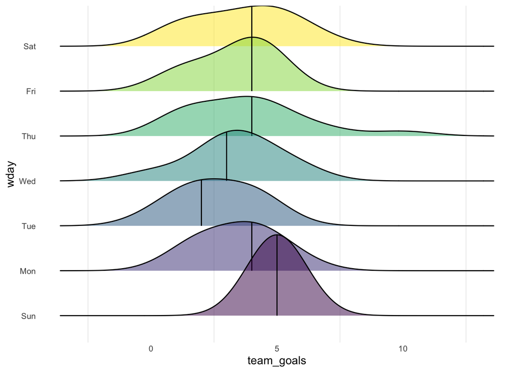

```r
games_jerseys %>%
        mutate(wday = factor(as.character(wday(date, label =T)),
                             levels = c("Sun",
                                        "Mon",
                                        "Tue",
                                        "Wed",
                                        "Thu",
                                        "Fri",
                                        "Sat"))) %>%
        ggplot(aes(x=team_goals,
                   fill= wday,
                   y = wday))+
        stat_density_ridges(quantile_lines = T,
                            alpha = 0.5,
                            quantiles = 0.5)+
        theme_phil()+
        scale_fill_viridis_d()+
        guides(fill = 'none')
```

What should the Stars do? Score more goals on Tuesdays. Easy.

## 3.4 Shots

Now analyse shots. Stars shots per game by jersey.

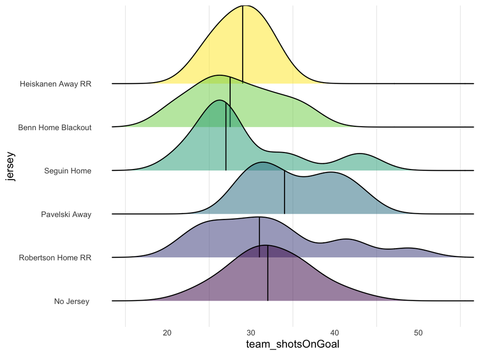

```r
# ridge
games_jerseys %>%
        mutate(jersey = clean_jersey(jersey)) %>%
        ggplot(aes(x = team_shotsOnGoal,
                   fill = jersey,
                   y = jersey))+
        stat_density_ridges(quantile_lines = T,
                            quantiles = 0.5,
                            alpha = 0.5)+
        theme_phil()+
        #  scale_fill_manual(values = c('grey60', 'yellow'))+
        guides(fill = 'none')+
        scale_fill_viridis_d()
```

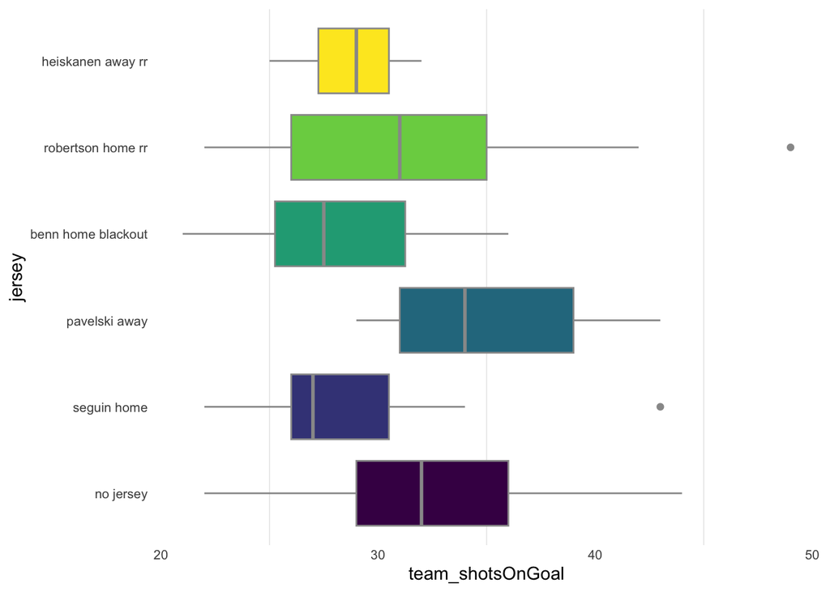

```r
# box plot
games_jerseys %>%
        ggplot(aes(x = team_shotsOnGoal,
                   fill = jersey,
                   y = jersey))+
        geom_boxplot(color = 'grey60')+
        theme_phil()+
        #  scale_fill_manual(values = c('grey60', 'yellow'))+
        guides(fill = 'none')+
        scale_fill_viridis_d()
```

```r
# fit model
lm = lm(team_shotsOnGoal ~ jersey + team_home_away + wday,
        data = games_jerseys %>%
                add_wday())

# coefs
lm %>%
        tidy() %>%
        clean_term() %>%
        mutate_if(is.numeric, round, 3) %>%
        add_gt()
```

| term | estimate | std.error | statistic | p.value |
| --- | --- | --- | --- | --- |
| (Intercept) | 32.647 | 3.407 | 9.582 | 0.000 |
| Seguin Home | -2.846 | 2.473 | -1.151 | 0.254 |
| Pavelski Away | 3.864 | 2.223 | 1.738 | 0.087 |
| Benn Home Blackout | -4.647 | 2.563 | -1.813 | 0.074 |
| Robertson Home RR | 1.143 | 2.012 | 0.568 | 0.572 |
| Heiskanen Away RR | -2.706 | 3.125 | -0.866 | 0.390 |
| Team Home | 1.030 | 1.345 | 0.766 | 0.446 |
| Mon | -2.730 | 3.764 | -0.726 | 0.471 |
| Tue | -1.157 | 3.699 | -0.313 | 0.755 |
| Wed | 1.904 | 3.855 | 0.494 | 0.623 |
| Thu | -0.565 | 3.744 | -0.151 | 0.881 |
| Fri | 0.333 | 4.026 | 0.083 | 0.934 |
| Sat | -2.477 | 3.643 | -0.680 | 0.499 |

```r
#rmarkdown::paged_table()

# glance
lm %>%
        glance() %>%
        mutate_if(is.numeric, round, 3)
```

```
## # A tibble: 1 × 12
##   r.squared adj.r.squared sigma statistic p.value    df logLik   AIC   BIC
##       <dbl>         <dbl> <dbl>     <dbl>   <dbl> <dbl>  <dbl> <dbl> <dbl>
## 1     0.173         0.029  5.69      1.20     0.3    12  -252.  532.  565.
## # ℹ 3 more variables: deviance <dbl>, df.residual <dbl>, nobs <dbl>
```

# 4 Grid Search

Alright I need to get more efficient here at running these tests, as I want to run them over individual periods.

```r
# get a dataset at the game period level
games_periods =
        games_jerseys %>%
        unnest(linescore_periods) %>%
        mutate(team_shotsOnGoal = case_when(team_home_away == 'home' ~ home.shotsOnGoal,
                                            team_home_away == 'away' ~ away.shotsOnGoal),
               team_goals = case_when(team_home_away == 'home' ~ home.goals,
                                      team_home_away == 'away' ~ away.goals)) %>%
        mutate(opponent_shotsOnGoal = case_when(team_home_away == 'away' ~ home.shotsOnGoal,
                                                team_home_away == 'home' ~ away.shotsOnGoal),
               opponent_goals = case_when(team_home_away == 'away' ~ home.goals,
                                          team_home_away == 'home' ~ away.goals)) %>%
        mutate(period = num) %>%
        select(date,
               gamePk,
               team_name,
               opponent_name,
               jersey,
               jersey_worn,
               jersey_type,
               period,
               team_home_away,
               team_shotsOnGoal,
               team_goals,
               opponent_shotsOnGoal,
               opponent_goals)
```

Now I’ll create some helper functions for fitting regressions and grabbing their output.

```r
add_formula = function(data, formula) {

        data %>%
                mutate(mod = deparse1(formula)) %>%
                mutate(outcome = sub(" .*", "", mod))

}


fit_poisson = function(formula, data) {

        glm(as.formula(formula),
            family = 'poisson',
            data) %>%
                tidy() %>%
                mutate_if(is.numeric, round, 3) %>%
                mutate(method = 'poisson') %>%
                add_formula(formula)

}

fit_lm = function(formula, data) {

        lm(as.formula(formula),
           data) %>%
                tidy(conf.int = T, conf.level = .8) %>%
                mutate_if(is.numeric, round, 3) %>%
                mutate(method = 'lm') %>%
                add_formula(formula)

}

unnest_mod = function(data) {

        data %>%
                unnest(mod) %>%
                select(mod, method, everything())

}

coef_plot = function(data, form) {

        data %>%
                filter(term != '(Intercept)') %>%
                arrange(p.value) %>%
                ggplot(aes(x=term,
                           y = estimate,
                           ymin = conf.low,
                           ymax = conf.high))+
                #  geom_pointrange(position = position_dodge(width = .5))+
                facet_wrap(form)+
                coord_flip()+
                theme_phil()+
                geom_hline(yintercept = 0,
                           linetype = 'dashed')


}
```

I’ll fit regressions to team and opponent goals per period, fitting a series of nested models at the period level.

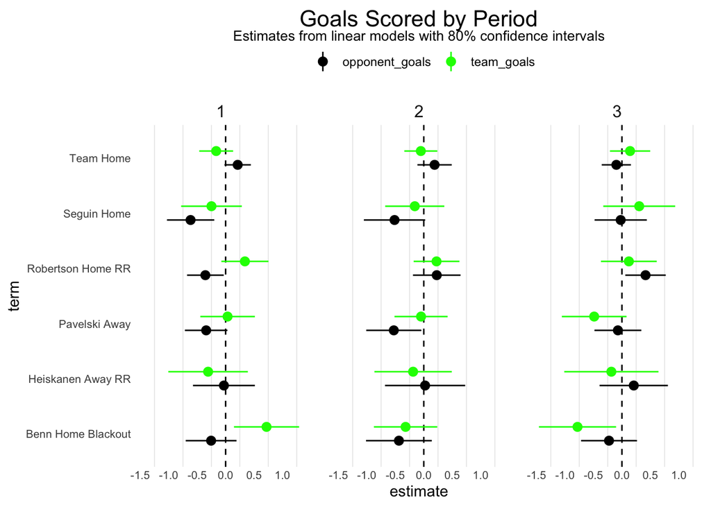

```r
# fit linear model to team goals
games_periods %>%
        add_wday() %>%
        nest(data = -period) %>%
        mutate(mod = map(data,
                         ~ fit_lm(formula = team_goals ~ jersey + team_home_away,
                                  data = .x))) %>%
        select(period, mod) %>%
        unnest_mod() %>%
        bind_rows(.,
                  games_periods %>%
                          add_wday() %>%
                          nest(data = -period) %>%
                          mutate(mod = map(data,
                                           ~ fit_lm(formula = opponent_goals ~ jersey + team_home_away,
                                                    data = .x))) %>%
                          select(period, mod) %>%
                          unnest_mod()
        ) %>%
        filter(period != 4) %>%
        clean_term() %>%
        coef_plot(period ~.)+
        theme(plot.subtitle = element_text(hjust = 0.5, size = 10))+
        geom_pointrange(aes(color = outcome),
                        position = position_dodge(0.5))+
        scale_color_manual(values = c("black", "green"))+
        ggtitle("Goals Scored by Period",
                subtitle = 'Estimates from linear models with 80% confidence intervals')
```

Same but for shots.

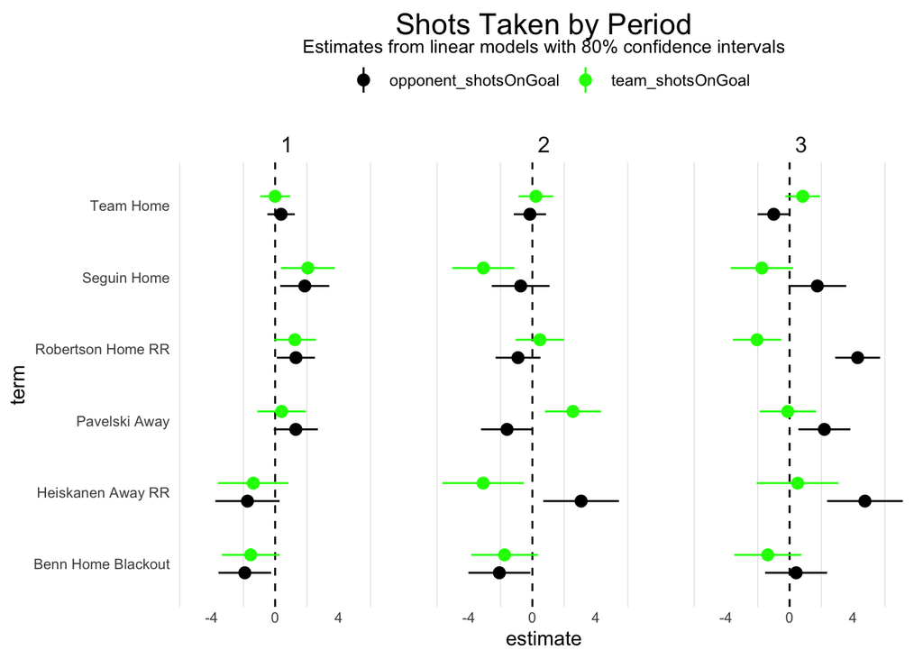

```r
# fit linear model to team goals
games_periods %>%
        add_wday() %>%
        nest(data = -period) %>%
        mutate(mod = map(data,
                         ~ fit_lm(formula = team_shotsOnGoal ~ jersey + team_home_away,
                                  data = .x))) %>%
        select(period, mod) %>%
        unnest_mod() %>%
        bind_rows(.,
                  games_periods %>%
                          add_wday() %>%
                          nest(data = -period) %>%
                          mutate(mod = map(data,
                                           ~ fit_lm(formula = opponent_shotsOnGoal ~ jersey + team_home_away,
                                                    data = .x))) %>%
                          select(period, mod) %>%
                          unnest_mod()
        ) %>%
        clean_term() %>%
        filter(period != 4) %>%
        coef_plot(period ~.)+
        theme(plot.subtitle = element_text(hjust = 0.5, size = 10))+
        geom_pointrange(aes(color = outcome),
                        position = position_dodge(0.5))+
        scale_color_manual(values = c("black", "green"))+
        ggtitle("Shots Taken by Period",
                subtitle = 'Estimates from linear models with 80% confidence intervals')
```

Booyah. Significant relationships for a bunch of these jerseys now. Science!

What about the shots percentage?

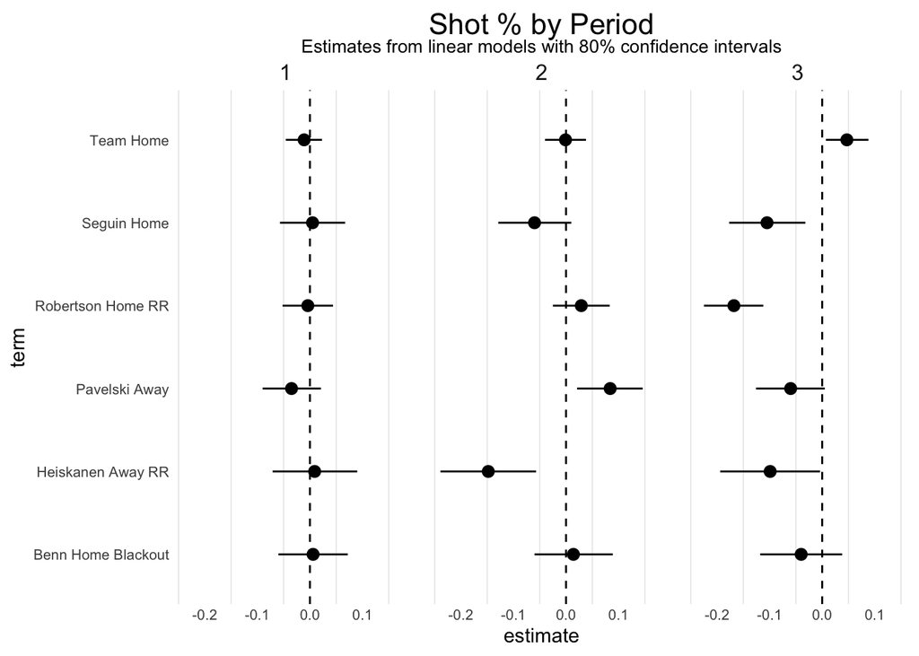

```r
# fit linear models to shot percentage
games_periods %>%
        mutate(team_shots_perc = team_shotsOnGoal / (team_shotsOnGoal + opponent_shotsOnGoal)) %>%
        add_wday() %>%
        nest(data = -period) %>%
        mutate(mod = map(data,
                         ~ fit_lm(formula = team_shots_perc ~ jersey + team_home_away,
                                  data = .x))) %>%
        select(period, mod) %>%
        unnest_mod() %>%
        clean_term() %>%
        filter(period != 4) %>%
        coef_plot(period ~.)+
        theme(plot.subtitle = element_text(hjust = 0.5, size = 10))+
        geom_pointrange(aes(color = outcome),
                        position = position_dodge(0.5))+
        scale_color_manual(values = c("black", "green"))+
        ggtitle("Shot % by Period",
                subtitle = 'Estimates from linear models with 80% confidence intervals')+
        guides(color = 'none')
```

Ayyyy we in business now.